# USA House Election Results

## Checking the assumptions of the models

I will check the models to see if the assumptions of linear regression (normality of the residuals, linearity of the relationships, homogeneity of variance/homoscedasticity, multicollinearity) hold true. I will also check the models for influential outliers.

### Checking the assumptions of the model for more conservative states

```r
# Testing for linearity of the model
raintest(model_conservative)
```

```
##
##  Rainbow test
##
## data:  model_conservative
## Rain = 1.1202, df1 = 396, df2 = 393, p-value = 0.13
```

The p-value of the Rainbow test is 0.13, which is higher than 0.05, so we can assume that the linearity assumption is met.

```r
#Testing homoskedasticity
ols_test_breusch_pagan(model_conservative)
```

```
##
##  Breusch Pagan Test for Heteroskedasticity
##  -----------------------------------------
##  Ho: the variance is constant
##  Ha: the variance is not constant
##
##                     Data
##  --------------------------------------------
##  Response : percent_of_votes
##  Variables: fitted values of percent_of_votes
##
##         Test Summary
##  ----------------------------
##  DF            =    1
##  Chi2          =    2.622405
##  Prob > Chi2   =    0.1053646
```

The Breusch-Pagan test’s p-value is higher than 0.05, so we can assume that the homoskedasticity assumption is met.

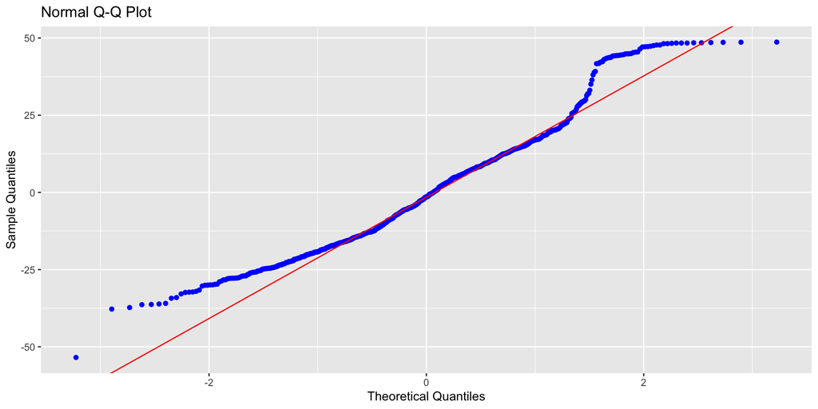

```r
#Testing for normality of residuals
ols_plot_resid_qq(model_conservative)
```

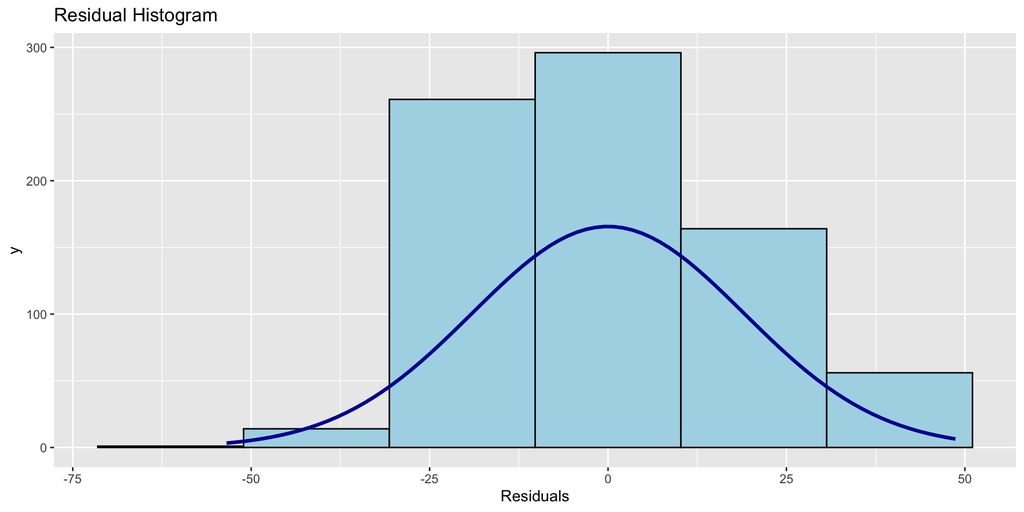

```r
ols_plot_resid_hist(model_conservative)
```

Based on the QQ-plot and the histogram, the normality assumption is a bit questionable, but I will assume that it is met. If this was a real study, I would probably investigate further or use a non-parametric test instead.

```r
#Testing for multicollinearity
ols_vif_tol(model_conservative)
```

```
##         Variables Tolerance      VIF
## 1 partyRepublican 0.9981012 1.001902
## 2            year 0.9981012 1.001902
```

The VIF and Tolerance values are really close to 1, so we can assume that the multicollinearity assumption is met.

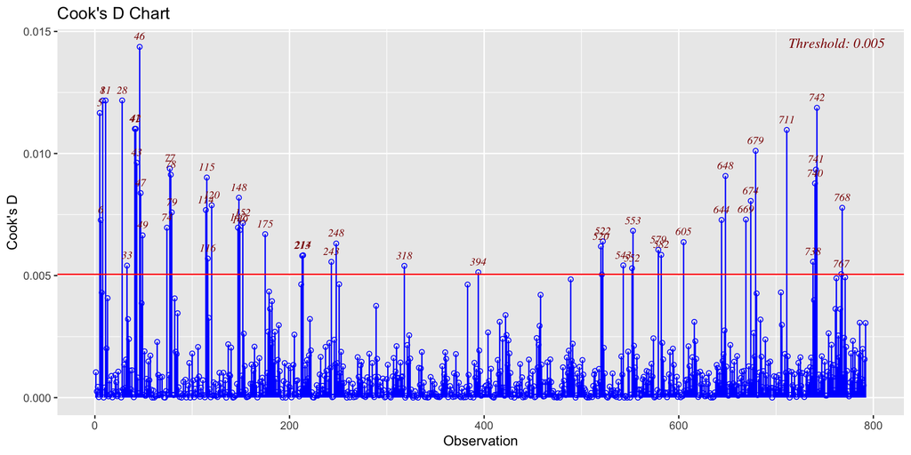

```r
#Testing for outliars
ols_plot_cooksd_chart(model_conservative)
```

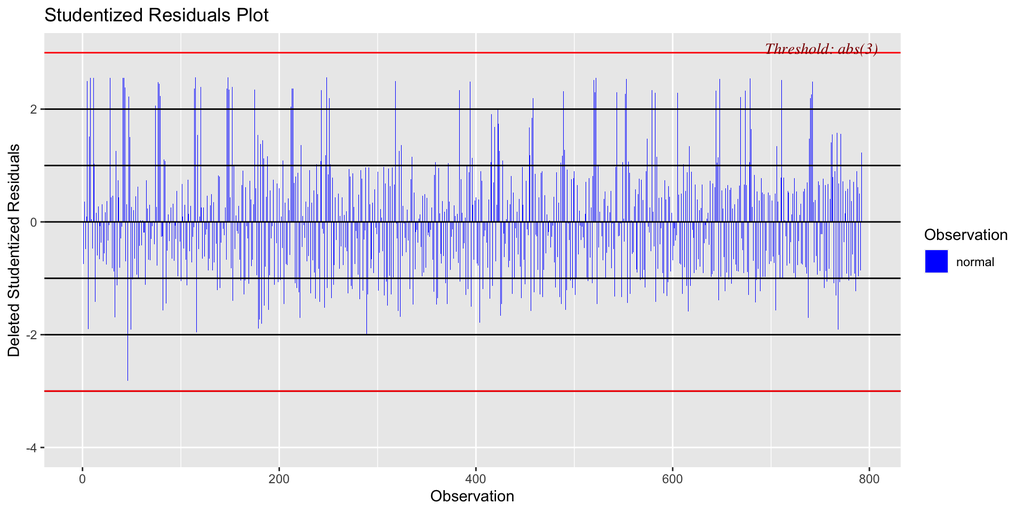

```r
ols_plot_resid_stud(model_conservative)
```

Based on the studentized residuals plot, there are no specific outliars, but the Cook’s distance plot shows that there are many influential points. However, this particular Cook’s distance plot uses an extremely conservative treshold.

### Checking the assumptions of the model for more progressive states

```r
# Testing for linearity of the model
raintest(model_progressive)
```

```
##
##  Rainbow test
##
## data:  model_progressive
## Rain = 0.86918, df1 = 2650, df2 = 2647, p-value = 0.9998
```

The p-value of the Rainbow test is 0.9998, so we can assume that the linearity assumption is met.

```r
#Testing homoskedasticity
ols_test_breusch_pagan(model_progressive)
```

```
##
##  Breusch Pagan Test for Heteroskedasticity
##  -----------------------------------------
##  Ho: the variance is constant
##  Ha: the variance is not constant
##
##                     Data
##  --------------------------------------------
##  Response : percent_of_votes
##  Variables: fitted values of percent_of_votes
##
##         Test Summary
##  ----------------------------
##  DF            =    1
##  Chi2          =    1.877391
##  Prob > Chi2   =    0.1706309
```

The Breusch-Pagan test’s p-value is higher than 0.05, so we can assume that the homoskedasticity assumption is met.

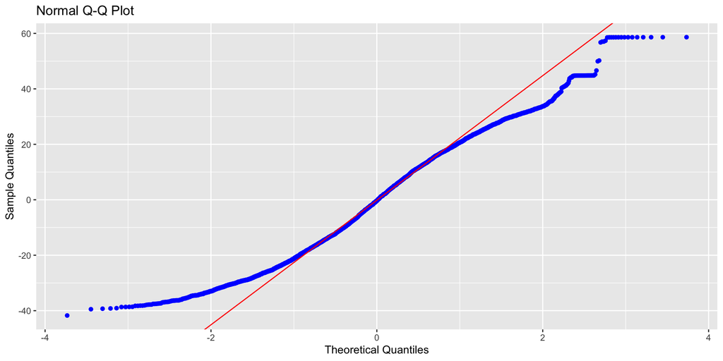

```r
#Testing for normality of residuals
ols_plot_resid_qq(model_progressive)
```

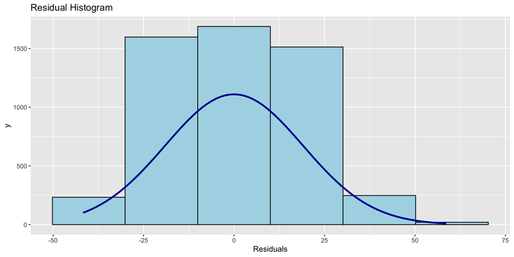

```r
ols_plot_resid_hist(model_progressive)
```

As with the previous model, based on the QQ plot and histogram, the normality assumption for this model is somewhat questionable, but I will assume that it is met. If this were a real study, I would probably investigate further.

```r
#Testing for multicollinearity
ols_vif_tol(model_progressive)
```

```
##         Variables Tolerance      VIF
## 1 partyRepublican 0.9994148 1.000586
## 2            year 0.9994148 1.000586
```

The VIF and Tolerance values are really close to 1, so we can assume that the multicollinearity assumption is met.

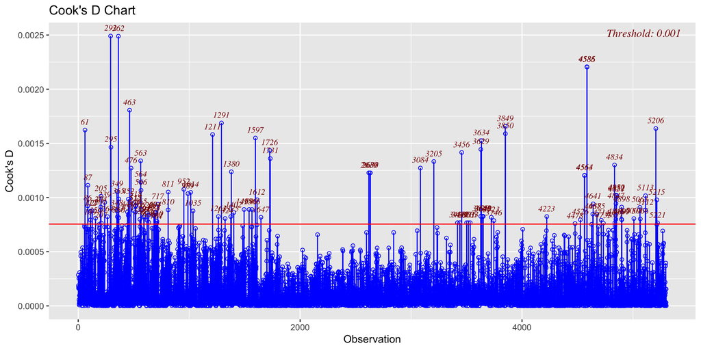

```r
#Testing for outliars
ols_plot_cooksd_chart(model_progressive)
```

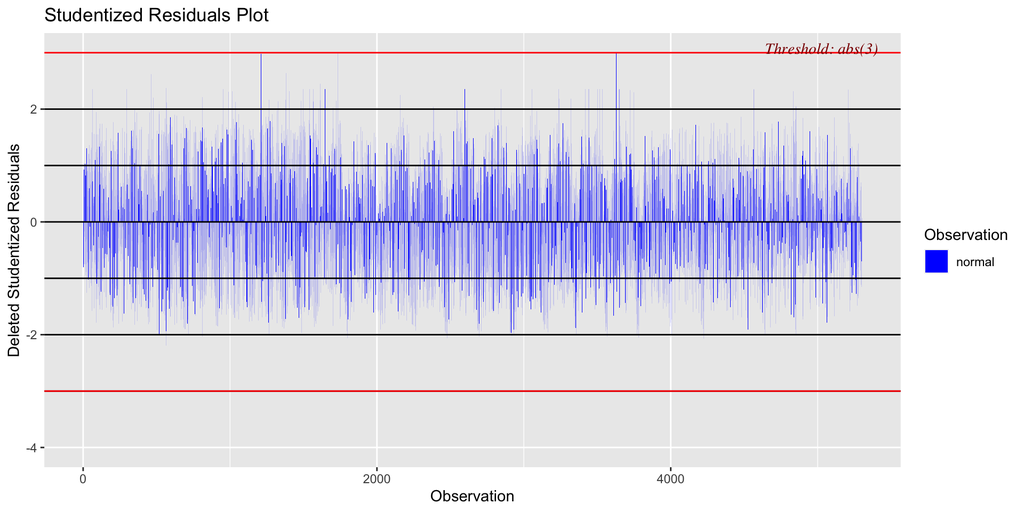

```r
ols_plot_resid_stud(model_progressive)
```

The results of the outlier testing are the same as for the previous model: based on the studentized residuals plot, there are no specific outliars, but the Cook’s distance plot shows that there are many influential points. However, this particular Cook’s distance plot uses an extremely conservative threshold.

## Comparing the models

```r
#Results of the model for more conservative states
summ(model_conservative, confint = TRUE)
```

```
## MODEL INFO:
## Observations: 792
## Dependent Variable: percent_of_votes
## Type: OLS linear regression
##
## MODEL FIT:
## F(2,789) = 4.81, p = 0.01
## R² = 0.01
## Adj. R² = 0.01
##
## Standard errors: OLS
## ----------------------------------------------------------------
##                           Est.     2.5%    97.5%   t val.      p
## --------------------- -------- -------- -------- -------- ------
## (Intercept)             124.96   -67.27   317.19     1.28   0.20
## partyRepublican           4.13     1.46     6.79     3.04   0.00
## year                     -0.04    -0.13     0.06    -0.76   0.45
## ----------------------------------------------------------------
```

The resulting model provided a significantly better prediction of the percentage of votes than the baseline model, F(2,789) = 4.81, p = 0.01, but the included independent variables explained only 1 percent of the variance in the dependent variable (adj. R-squared = 0.01). This suggests that the model does not capture a really big proportion of the variability in vote percentages in traditionally conservative states. Of the independent variables, only the party variable showed a significant relationship with the dependent variable, while year did not. The unstandardized coefficient of the partyRepublican variable was 4.13, indicating that the predicted percentage of votes for Republican Party candidates was 4.13 percentage points higher than the predicted percentage of votes for Democratic Party candidates.

```r
#Results of the model for more progressive states
summ(model_progressive, confint = TRUE)
```

```
## MODEL INFO:
## Observations: 5300
## Dependent Variable: percent_of_votes
## Type: OLS linear regression
##
## MODEL FIT:
## F(2,5297) = 347.64, p = 0.00
## R² = 0.12
## Adj. R² = 0.12
##
## Standard errors: OLS
## ----------------------------------------------------------------
##                           Est.     2.5%    97.5%   t val.      p
## --------------------- -------- -------- -------- -------- ------
## (Intercept)              51.75   -22.08   125.58     1.37   0.17
## partyRepublican         -13.80   -14.83   -12.78   -26.36   0.00
## year                      0.00    -0.04     0.04     0.09   0.93
## ----------------------------------------------------------------
```

```r
#Comparing the models
export_summs(model_conservative, model_progressive,
             model.names = c("Conservative states", "Progressive states"),
             error_format = "[{conf.low}, {conf.high}]")
```

|  | Conservative states | Progressive states |
| --- | --- | --- |
| (Intercept) | 124.96 | 51.75 |
|  | [-67.27, 317.19] | [-22.08, 125.58] |
| partyRepublican | 4.13 ** | -13.80 *** |
|  | [1.46, 6.79] | [-14.83, -12.78] |
| year | -0.04 | 0.00 |
|  | [-0.13, 0.06] | [-0.04, 0.04] |
| N | 792 | 5300 |
| R2 | 0.01 | 0.12 |
| *** p < 0.001; ** p < 0.01; * p < 0.05. |  |  |

We can conlude that our model for traditionally progressive states is a better predictor of the percentage of votes won than the model for traditionally conservative states. The model for progressive states explained 12 percent of the variance in the dependent variable, while the model for conservative states explained only 1 percent of the variance. It is interesting to note that the party variable was significant in both models, but the direction of the relationship was the opposite: in traditionally conservative states, the predicted percentage of votes for Republican Party candidates was 4.13 percentage points higher than the predicted percentage of votes for Democratic Party candidates; while in traditionally progressive states, the predicted percentage of votes for Republican Party candidates was 13.80 percentage points lower than the predicted percentage of votes for Democratic Party candidates. The year variable was not significant in either model.

[figure not shown]